# Item Fit

Psychologische Institut für psychologische Methodenlehre, Evaluation und Statistik

Carolina Fellinghauer

carolina.fellinghauer@uzh.ch

25 3 2020

# Getting ready

If the packages are not ready installed on your computer run the package installation file. Then we include the libraries:

```r
# install and load following R-packages
library(eRm)
library(iarm)
library(PP)
library(rms)
library(R2R)
library(splines)
```

and load the Stress Related Growth data (SRG) :

```r
# get the SRG dataset from GitHub

urlfile <- "https://raw.githubusercontent.com/CarolinaFellinghauer/UNIZH_HS2020_Rasch/master/Data/SRG_Data_Course_UNIZH.csv?token=AB5GB47UIUWV7F5NMGA33T27K5IQ2"

srg.data <- read.csv(url(urlfile))

dim(srg.data)
```

```
[1] 450  26
```

```r
colnames(srg.data)
```

```
 [1] "X"                      "ID"                     "Age"
 [4] "Gender"                 "Completeness"           "para.tetra_1"
 [7] "traumatic_nontraumatic" "PersStat"               "SRG1"
[10] "SRG2"                   "SRG3"                   "SRG4"
[13] "SRG5"                   "SRG6"                   "SRG7"
[16] "SRG8"                   "SRG9"                   "SRG10"
[19] "SRG11"                  "SRG12"                  "SRG13"
[22] "SRG14"                  "SRG15"                  "TP"
[25] "ID_Unik"                "wgt"
```

```r
srg.items <- c("SRG1", "SRG2", "SRG3", "SRG4", "SRG5", "SRG6", "SRG7", "SRG8", "SRG9",
    "SRG10", "SRG11", "SRG12", "SRG13", "SRG14", "SRG15")


# dataset with only the SRG items
data.srg <- srg.data[, srg.items]

# check response coding (frequencies including missing values) for each SRG-item
apply(data.srg, 2, table, useNA = "always")
```

```
     SRG1 SRG2 SRG3 SRG4 SRG5 SRG6 SRG7 SRG8 SRG9 SRG10 SRG11 SRG12 SRG13 SRG14
0     163  256  128  142  117  161  161  205  139    88   138   259    64   144
1     221  139  201  177  155  171  174  164  211   237   203   143   206   174
2      62   51  120  129  178  116  115   81  100   124   109    47   180   131
<NA>    4    4    1    2    0    2    0    0    0     1     0     1     0     1
     SRG15
0       63
1      159
2      228
<NA>     0
```

# Item Fit

Item fit statistics are commonly reported in validation studies with the Rasch model, as they indicate how well items describe the continuum of a latent trait. The item fit shows if the assumption of monotonicity can be supported, i.e. that the expected value of an item score increases when the values of the latent variable increases. Several approaches to test if an item fits the scale exist, the most commonly used are :

- infit and outfit mean squares
- visual analysis

## Infit and Outfit

Infit and outfit are mean-square residual summary statistics that range from zero to infinity.

To find the item fit requires:

1. to calculate the **expected response for each observation** $X_{ij}$, i.e. the response for item $i$ and person $j$ based on the estimated person and item parameter.

$$E_{ij} = \Sigma^{mi}_{k=0} k (P_{ikj})$$

$P_{ikj}$ is the probability of a person $j$ responding $k$ on item $i$, $k$ being the available response categories which are set to start from zero.

2. to calculate a **score residual** $Y_{ij}$:

$$Y_{ij} = X_{ij} - E_{ij}$$
and a **standardized residual** $Z_{ij}$:

$$Z_{ij} = \frac{Y_{ij}}{(W_{ij})^{1/2}}$$

where $W_{ij} = \Sigma^{mi}_{k=0}(k-E_{ij})^2 P_{ikj}$ is the variance of $X_{ij}$.

3. The standardized residuals are squared and summed to form a **Chi-square statistic**:

$$\chi^2 = \Sigma^N_{n=1}Z_{ij}^2$$

4. The chi-square statistic divided by N corresponds to the **Mean-Square Outfit statistic**

$$Outfit_i = \frac{(\Sigma^N_{n=1}Z_{ij}^2)}{N}$$

The outfit statistic is sensitive to outlier, i.e. off-target information.

5. to diminish this effect of the Outfit statistic, the **Mean-Square Infit** adjusts the squared standardized residuals $Z_{ij}^2$, by their individual variances, $W_{ij}$:

$$Infit_{i} = \frac{\Sigma^N_{n=1}W_{ij}Z_{ij}^2}{\Sigma^N_{n=1}W_{ij}}$$

## Underfit and Overfit

Under the null hypothesis, the expected value of the Infit and Outfit statistic of a fitting item is equal to one. Values much greater than one (> 1.3 for example) indicate **underdiscrimination** while values below one (< 0.7 for example) **overdiscrimination**.

**Underdiscriminating** items do not allow to differentiate person on a cut-off, the information is ‘blurred’. The sample cannot be stratified or measured with underdiscriminating items.

**Overdiscriminating** items are too ‘sharp’ and do not add any information about relative performances to the scale. Overdiscriminating items act like an on/off switch but not like a measuring device.

In general underdiscriminating items are more a problem for a measurement scale than overdiscriminating items.

# Diagnostics

## Numeric Output Analysis

To calculate the item fit with `eRm` requires the `itemfit()` function which uses the output of the `person.parameter` object.

```r
# starting with the PCM analysis
PCM.srg <- PCM(data.srg)

# first apply the person.parameter from the PCM run previously
PP.srg <- person.parameter(PCM.srg)

# second apply itemfit()
Fit <- itemfit(PP.srg)
Fit
```

```
Itemfit Statistics:
        Chisq  df p-value Outfit MSQ Infit MSQ Outfit t Infit t Discrim
SRG1  410.605 433   0.774      0.946     0.960   -0.762  -0.618   0.567
SRG2  450.201 433   0.274      1.037     1.039    0.373   0.602   0.528
SRG3  480.948 436   0.067      1.101     1.036    1.474   0.607   0.558
SRG4  454.647 435   0.249      1.043     1.091    0.604   1.493   0.533
SRG5  398.017 437   0.909      0.909     0.936   -1.160  -1.037   0.628
SRG6  311.574 435   1.000      0.715     0.746   -4.151  -4.630   0.727
SRG7  329.001 437   1.000      0.751     0.771   -3.598  -4.132   0.710
SRG8  369.681 437   0.991      0.844     0.916   -1.891  -1.379   0.607
SRG9  368.674 437   0.992      0.842     0.852   -2.487  -2.550   0.649
SRG10 381.449 436   0.972      0.873     0.884   -2.110  -1.970   0.611
SRG11 464.429 437   0.176      1.060     1.024    0.899   0.423   0.557
SRG12 389.704 436   0.946      0.892     0.928   -1.005  -1.075   0.580
SRG13 449.976 437   0.324      1.027     1.007    0.425   0.131   0.522
SRG14 348.163 436   0.999      0.797     0.836   -2.948  -2.869   0.681
SRG15 721.151 437   0.000      1.646     1.437    6.438   5.916   0.337
```

The columns `Outfit MSQ` and `Infit MSQ` are those we are interested in. The way to interpret this output can vary. Is it a population survey or is the scale for clinical use? How much is at stake? For the moment, we will rely on the cut-off values proposed by (Wright et al. 1994) here https://www.rasch.org/rmt/rmt83b.htm.

For a high stake test the infit and outfit statistics should be between 0.8 and 1.2 if items are fitting the Rasch scale.

The output shows that a few items are overdiscriminating with values $< 0.8$: SRG-6 and SRG-7 and SRG-14 for the outfit only. Only one item is underdiscriminating and really problematic. Item SRG-15 *I learned that there are more people who care about me than I thought* have outfit and infit values of `1.646` and `1.437` which is far beyond an acceptable value.

## Visual Analysis

Item fit problems can be detected with the item-category characteristic (ICC) curve. In principle, the ICC is used to observe the probabilities for item responses across the ability continuum. The following ICC plots show the expected response probability curve for an item along the ability continuum. Dots illustrate the true position of the respondents (or respondents groups) along the continuum.

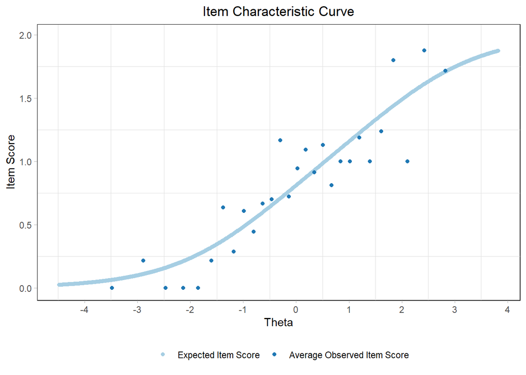

```r
ICCplot(data.srg, itemnumber = 1, method = "score")
```

The option `cinumber` divides the score continuum into the specified number of sample subgroups with all subgroups having approximately the same number of observations.

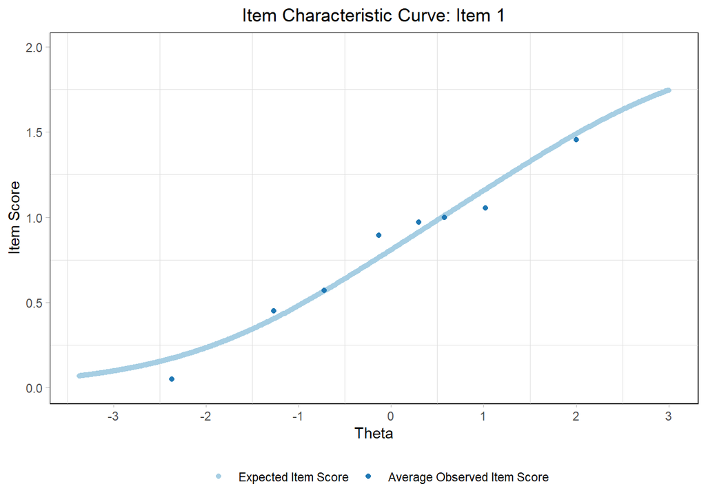

```r
ICCplot(data.srg, itemnumber = 1, method = "cut", cinumber = 8, title = "Item Characteristic Curve: Item 1")
```

This plot shows the item characteristic version and see that the mean observed scores per class interval (the dots) are well aligned along the curve.

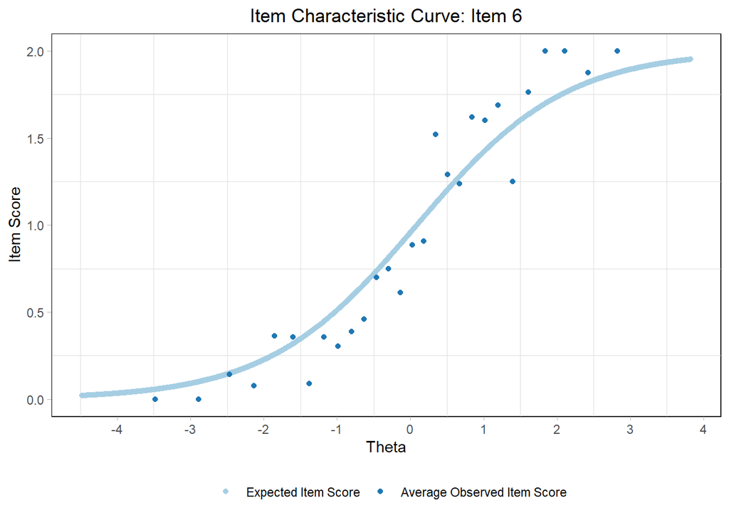

```r
ICCplot(data.srg, itemnumber = 6, method = "score", title = "Item Characteristic Curve: Item 6")
```

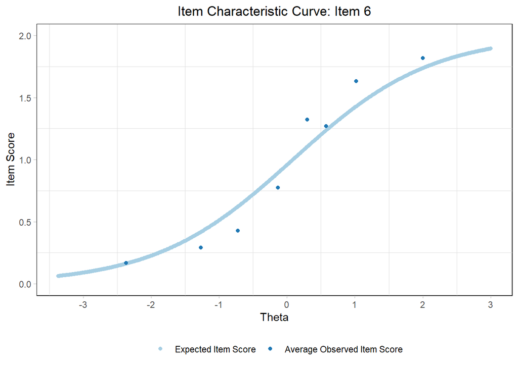

```r
ICCplot(data.srg, itemnumber = 6, method = "cut", cinumber = 8, title = "Item Characteristic Curve: Item 6")
```

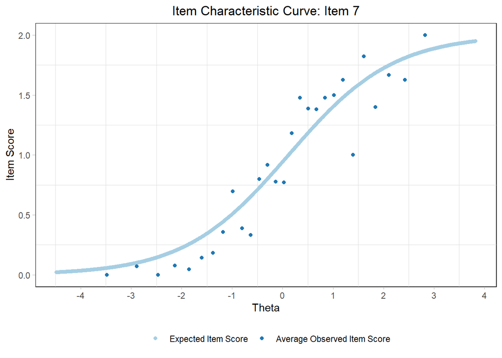

```r
ICCplot(data.srg, itemnumber = 7, method = "score", title = "Item Characteristic Curve: Item 7")
```

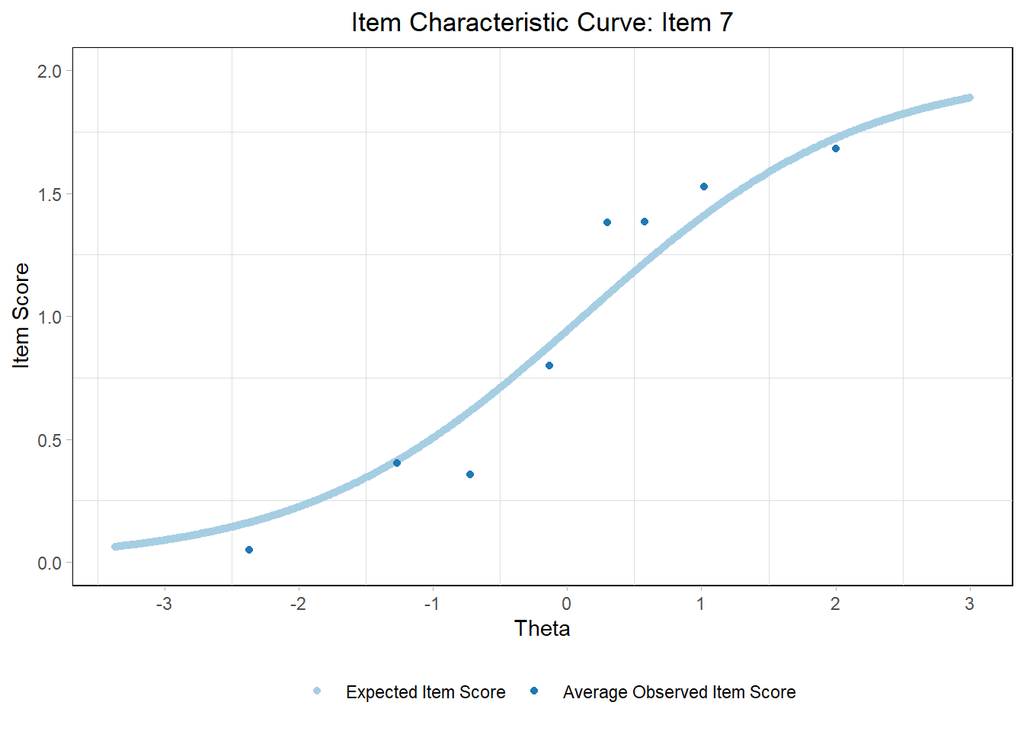

```r
ICCplot(data.srg, itemnumber = 7, method = "cut", cinumber = 8, title = "Item Characteristic Curve: Item 7")
```

These are two of the items that showed some overfit earlier. It can be noticed, that the increase in the observed scores (the dots) is somewhat steeper than the estimated ICC curve. That is commonly observed in presence of overfit.

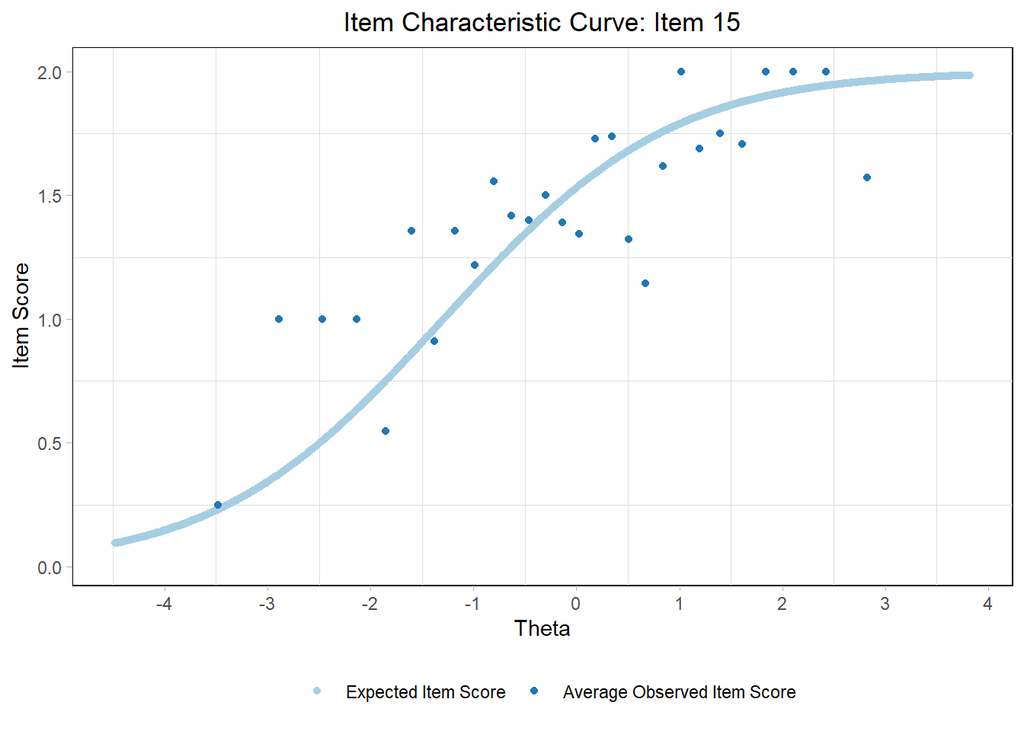

```r
ICCplot(data.srg, itemnumber = 15, method = "score", title = "Item Characteristic Curve: Item 15")
```

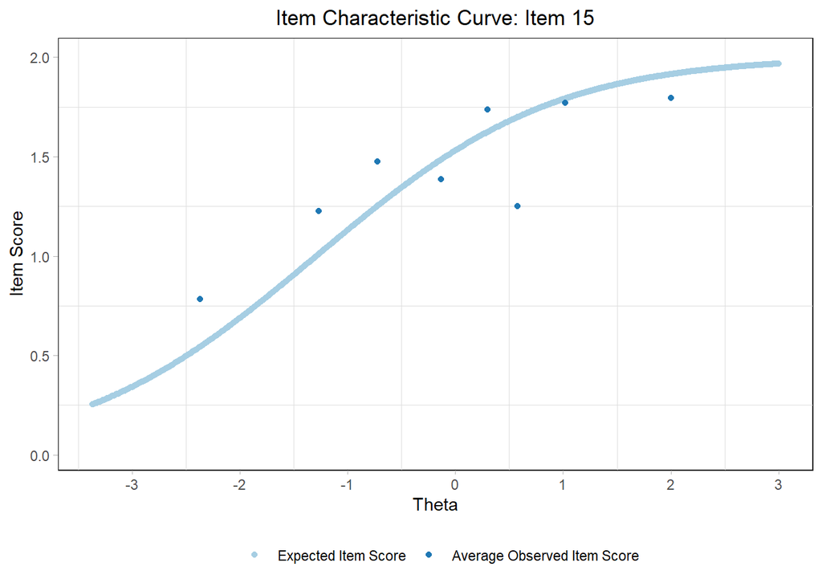

```r
ICCplot(data.srg, itemnumber = 15, method = "cut", cinumber = 8, title = "Item Characteristic Curve: Item 15")
```

The item 15 was the only item which was underfitting. It can be noticed, that the increase in the observed scores (the dots) is not consistently following the estimated ICC curve and that the observed change in observed score is flatter than predicted.

# Exercise

Smith (1998, p.78) suggests cut-off based on sample sizes. Have a look at the article. Write down the two formulas and calculate the reasonable cut-offs for infit and outfit. Discuss item fit of the SRG-data under this light.

# References

Wright, B. D., J. M. Linacre, J. E. Gustafson, and P. Martin-Loef. 1994. “Reasonable Mean-Square Fit Values.” *Rasch Measurement Transactions* 8 (3): 370.